# Studienleistung 1

Götz, Lukas (2094420) [lukas-matthias.goetz@stud.uni-bamberg.de]

Hodys, Nils (2094436) [nils.hodys@stud.uni-bamberg.de]

2022-11-23

## Aufgabe 1: Allgemeine Fragen zu R

### a) Wie eignet sich R, um Fragestellungen im ASN Kontext lösen zu können? Geben Sie dazu drei Anwendungsbeispiele an.

- Plotten von Netwerken anhand gegebener Werte
- Statistische Auswertung (Bspw. Berechnung durchschnittlicher oder kürzester Pfadlängen)
- Matritzenrechnung durchführen

### b) Welche grundlegenden Datenstrukturen gibt es in R und was sind deren Eigenschaften?

- *Vector* Eine eindimensionale, endliche Sammlung mit fester Reihenfolge von Elementen gleichen Datentyps
- *List* Eine Sammlung mit fester Reihenfolge von beliebigen Datentypen
- *Dataframe* DataFrames: DataFrames sind vergleichbar mit Tabellen, in denen die Spalten die Variablennamen darstellen und die Zeilen die jeweiligen Werte. Sie sind Listen von Vektoren bzw. Faktoren mit der gleichen Länge.
- *Matrix* Matrizen sind Erweiterungen von Vektoren, sie sind Vektoren mit Dimensionen
- *Factor* Faktoren ähneln Vektoren und können kategoriale Daten enthalten

### c) Wie können Sie in R einen Datentyp in einen anderen Datentyp umwandeln?

`as.integer`, `as.character`, …

### d) In der Übung und im Skript haben Sie die grundlegende Syntax von R kennengelernt. Erläutern Sie, wofür folgender Befehle eingesetzt werden:

1. `#` Einfacher Kommentar
2. `""` String
3. `<-` Zuweisung (nach links)
4. `\` Escape-Character

## Aufgabe 2: Fragen zu igraph

### a) Aus der Übung ist Ihnen das Package igraph bekannt. Beschreiben sie kurz dessen Verwendung und Funktionen. Installieren und Laden Sie es anschließend in R Studio.

igraph ist eine Bibliothek mit entsprechenden Algorithmen und Strukturen zur Analyse von relationalen Daten und Netzwerken in R.

```r
# install.packages("igraph")
library(igraph)
```

### b) Betrachten wir nun den fiktiven Ort Graphingen. Graphingen besteht aus 9 Ortsteilen. Erstellen sie zur Abbildung dafür zunächst den Graph g aus neun Knoten und keinen Kanten. Plotten Sie den Graphen.

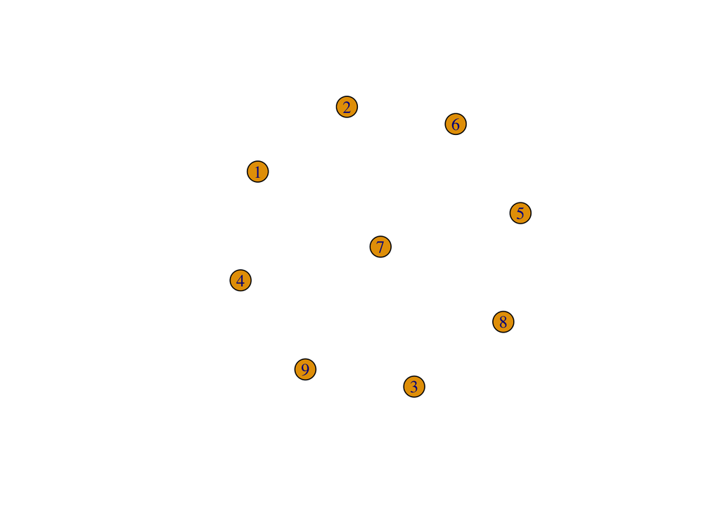

```r
Graphingen <- make_empty_graph(n = 9, directed = FALSE)
plot.igraph(Graphingen)
```

### c) Graphingen soll schöner werden. Ändern sie, die Form der Knoten in Quadrate und die Farbe in Grün.

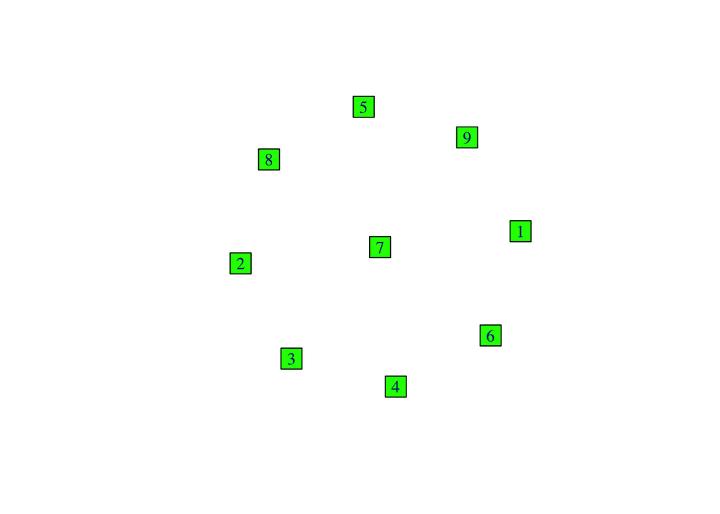

```r
plot.igraph(Graphingen, vertex.shape="square", vertex.color="green")
```

### d) Graphingen bekommt neue öffentliche Verkehrsmittel. 8 Verbindungen kommen dabei durch die neuen Buslinien hinzu. Stellen sie die Buslinien in Form von Kanten zwischen beliebigen Knoten dar, sodass jeder Knoten mit dem Netzwerk verbunden ist.

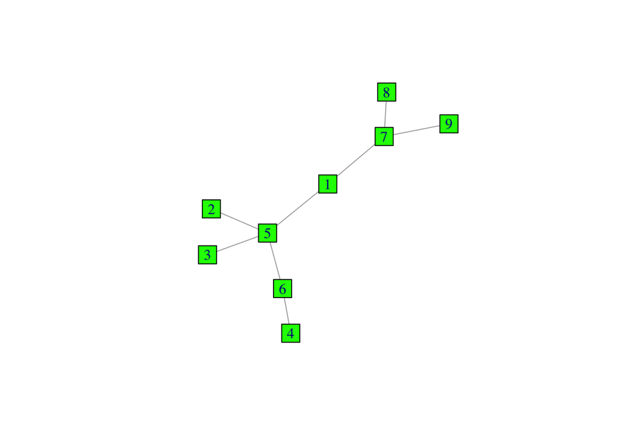

```r
Graphingen <- add_edges(Graphingen, c(1,5, 2,5, 3,5, 4,6, 5,6, 7,8, 7,9, 1,7))
plot.igraph(Graphingen, vertex.shape="square", vertex.color="green")
```

### e) Zuziehende gründen neue Vororte in Graphingen. Erhöhen sie die Anzahl der Knoten um 3 und binden Sie diese an das Bussystem an.

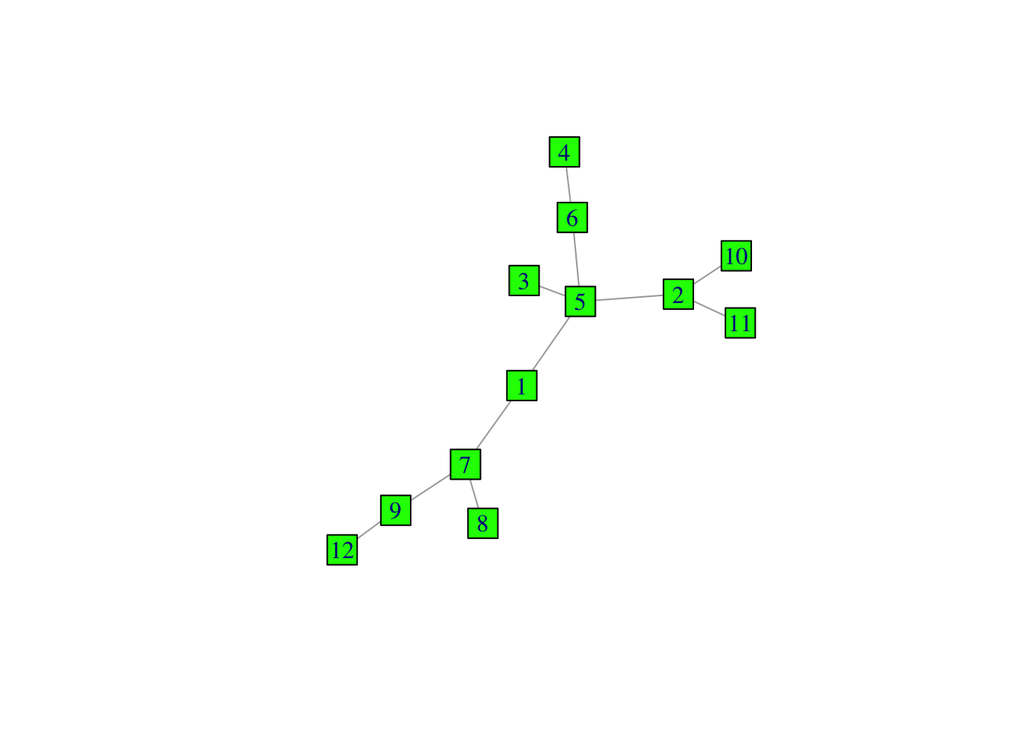

```r
Graphingen <- add_vertices(Graphingen, 3) %>%
  add_edges(c(2,10, 2,11, 9,12))

plot.igraph(Graphingen, vertex.shape="square", vertex.color="green")
```

### f) Durch eine Knappheit an Busfahrer:innen kann nicht jeder Ortsteil gleich häufig befahren werden. Stellen sie die Kanten im ursprünglichen Ortskern als starke Kanten und die Kanten zu den neuen Ortsteilen als schwache Kanten dar.

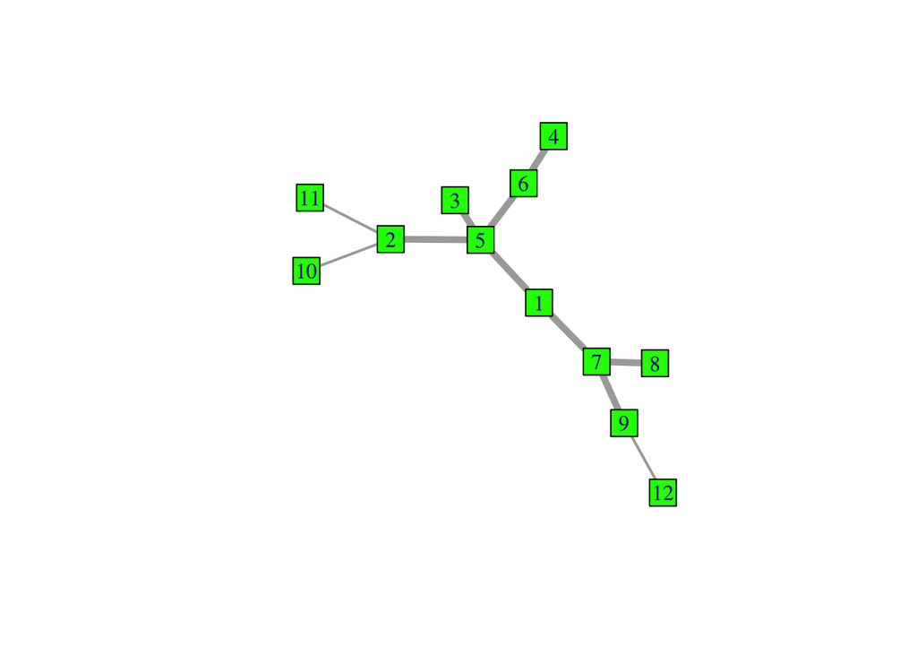

```r
Graphingen <- set_edge_attr(Graphingen, "weight", index = 1:8, 5)
Graphingen <- set_edge_attr(Graphingen, "weight", index = 9:11, 2)

plot.igraph(
  Graphingen, vertex.shape="square",
  vertex.color="green",
  edge.width=E(Graphingen)$weight
)
```

### g) Die Ortsteile von Graphingen werden nun in die Buszone A und Buszone B eingeteilt. Teilen Sie jeden Ortsteil in eine der Buszonen ein und fügen Sie die Gruppenzugehörigkeit als Attribut zu jedem Knoten hinzu.

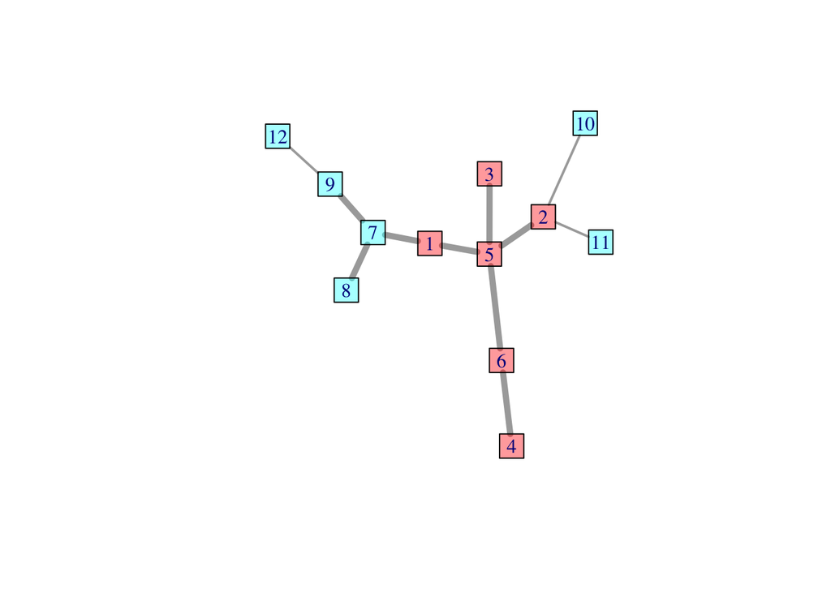

```r
Graphingen <- set_vertex_attr(Graphingen, "buszone", index = 1:6, "A")
Graphingen <- set_vertex_attr(Graphingen, "buszone", index = 7:12, "B")



plot.igraph(
  Graphingen,
  vertex.shape="square",
  vertex.color=rainbow(2, alpha=0.4)[as.factor(V(Graphingen)$buszone)],
  edge.width=E(Graphingen)$weight
)
```

### h) Erstellen Sie nun eine graphische Darstellung von Graphingen. Knoten sollen hier als Quadrate dargestellt und in der Farbe ihrer Zuteilung zu der Buszone visualisiert und gelabelt werden (Sie können sich hier Farben aussuchen). Färben Sie außerdem die Kanten entsprechend ihres Kantengewichtes ein (Sie können sich hier Farben aussuchen).

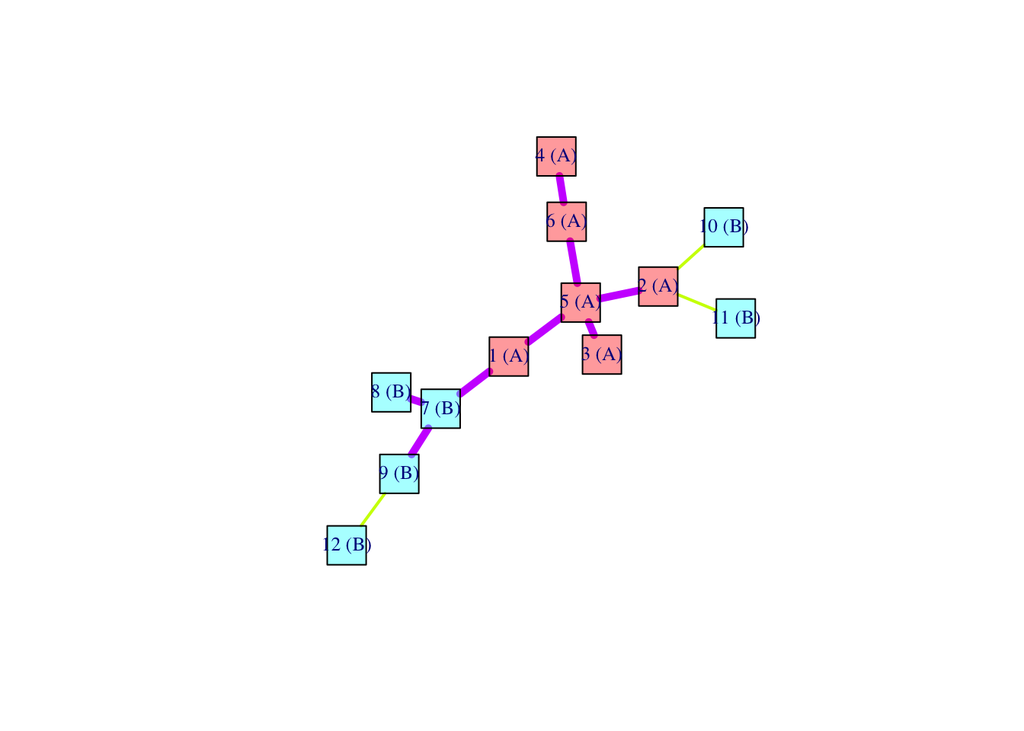

```r
plot.igraph(
  Graphingen,
  vertex.label = sprintf("%s (%s)", V(Graphingen), V(Graphingen)$buszone),
  vertex.label.cex = 0.8,
  vertex.shape="square",
  vertex.color=rainbow(2, alpha=0.4)[as.factor(V(Graphingen)$buszone)],
  vertex.size=20,
  edge.width=E(Graphingen)$weight,
  edge.color=rainbow(5)[E(Graphingen)$weight]
)
```

## Aufgabe 3: Import und Visualisierung eigener Daten

### a) Laden Sie sich den Datensatz zu „Game of Thrones“ aus dem VC herunter. Importieren Sie den Datensatz in R. Achten Sie hier darauf, dass der Datensatz in einem csv Format vorliegt. Laden Sie daher den Datensatz als Dataframe in R und transformieren Sie die Da- ten dann zu einem ungerichteten Graphenobjekt.

```r
got_edgelist <- read.csv("got_dataset.csv", header = TRUE, sep = ";")
GoT <- graph_from_data_frame(got_edgelist, directed = FALSE)
```

### b) Wie viele Knoten, wie viele Kanten hat der Graph? Welcher Knoten taucht am häufigsten als „Source“ und welcher am häufigsten als „Target“ auf? Welche beiden Charaktere haben die stärkste Beziehung?

```r
sprintf("%s Knoten", vcount(GoT)) # Anzahl Knoten
```

```
## [1] "317 Knoten"
```

```r
sprintf("%s Kanten", ecount(GoT)) # Anzahl Kanten
```

```
## [1] "760 Kanten"
```

```r
library(dplyr)
# Häufigste Source
got_edgelist %>%
  group_by(Source) %>%
  summarize(count = length(Source)) %>%
  arrange(desc(count)) %>%
  filter(row_number()==1)
```

| Source | count |
| --- | --- |
| Daenerys-Targaryen | 45 |

```r
# Häufigstes Target
got_edgelist %>%
  group_by(Target) %>%
  summarize(count = length(Target)) %>%
  arrange(desc(count)) %>%
  filter(row_number()==1)
```

| Target | count |
| --- | --- |
| Stannis-Baratheon | 38 |

```r
# Größtes Kantengewicht
got_edgelist %>%
  arrange(desc(weight)) %>%
  filter(row_number()==1)
```

| Source | Target | weight |
| --- | --- | --- |
| Daenerys-Targaryen | Hizdahr-zo-Loraq | 96 |

### c) Sind alle Charaktere s- miteinander verbunden, dass jeder Charakter jeden anderen Charakter im Netzwerk erreichen kann?

```r
components(GoT)$no
```

```
## [1] 1
```

Der Graph besteht aus 1 zusammenhängender component.

### d) Plotten Sie das Netzwerk. Beachten Sie dazu folgende Vorgaben:

- Verändern Sie die Margins des Plots mit der Funktion par() zu (1,1,1,1), so- dass der Graph in einer gut sichtbaren Größe dargestellt wird.
- Plotten Sie den Graphen mit dem Layoutalgorithmus Fruchterman-Reingold.
- Plotten Sie den Graphen als ungerichteten Graphen.
- Verändern Sie die Farbe der Knoten zu gelb.
- Verändern Sie die Farbe der Umrandung der Knoten zu blau.
- Plotten Sie die Knoten mit der Größe 5.
- Plotten Sie den Graphen ohne Labels.
- Plotten Sie die Kanten mit einem Gewicht von 1, um alle Verbindungen gleich zu gewichten.

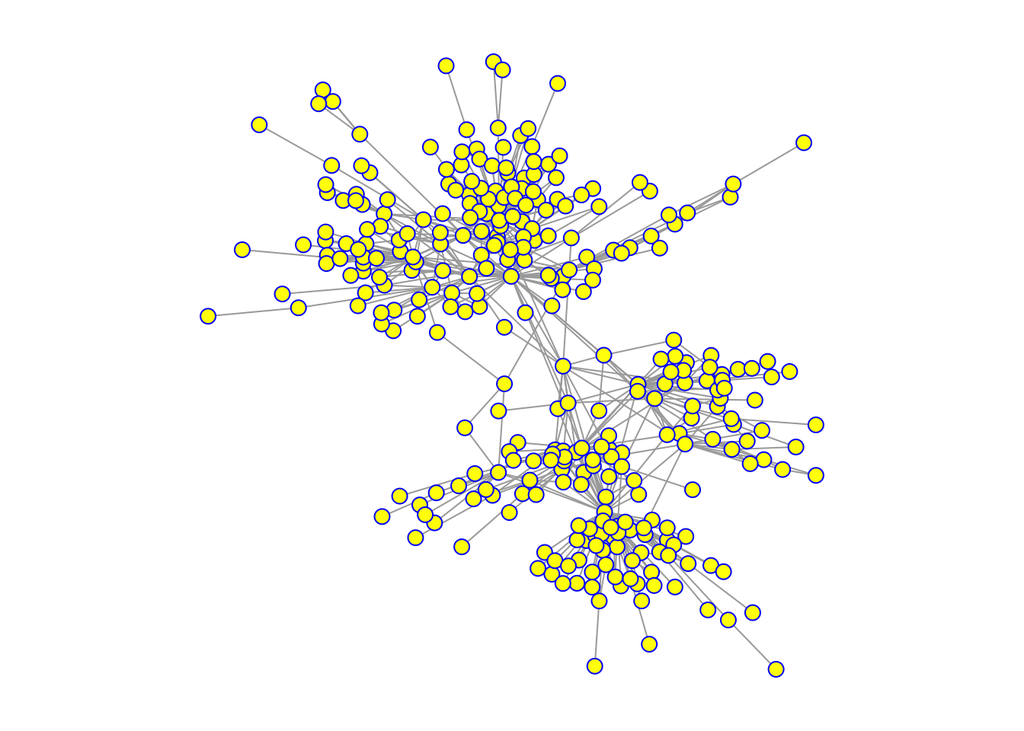

```r
fruchterman_reingold <- layout_with_fr(GoT)
par(mar=c(1,1,1,1))
plot.igraph(
  GoT,
  layout = fruchterman_reingold,
  vertex.color = "yellow",
  vertex.frame.color = "blue",
  vertex.size = 5,
  vertex.label = NA,
  edge.width = 1
)
```

### e) Nun sollen die Charaktere mit sehr starken Beziehungen gefunden werden. Reduzieren Sie dazu den Datensatz auf Charaktere, die mindestens ein Kantengewicht von 60 haben. Plotten Sie den Graphen mit den Angaben aus Aufgabe d). Verändern Sie hier nur die Größe der Knoten auf 10 und plotten Sie die Namen der Knoten mit gut lesbaren Labels. Was sind die Namen der Charaktere, die in diesem Graphen noch vorhanden sind?

[figure not shown]

```r
got_edgelist_strongties = got_edgelist[(got_edgelist$weight > 60),]
GoT_strongties <- graph_from_data_frame(got_edgelist_strongties, directed = FALSE)

fruchterman_reingold <- layout_with_fr(GoT_strongties)
par(mar=c(1,1,1,1))

plot.igraph(
  GoT_strongties,
  layout = fruchterman_reingold,
  vertex.color = "yellow",
  vertex.frame.color = "blue",
  vertex.size = 10,
  vertex.label.color = "black",
  vertex.label.font = 2,
  edge.width = 1
)
```